# test_a_Perceptual_Phenomenon

### Analyzing the Stroop Effect

Perform the analysis in the space below. Remember to follow [the instructions](https://docs.google.com/document/d/1-OkpZLjG_kX9J6LIQ5IltsqMzVWjh36QpnP2RYpVdPU/pub?embedded=True) and review the [project rubric](https://review.udacity.com/#!/rubrics/71/view) before submitting. Once you've completed the analysis and write-up, download this file as a PDF or HTML file, upload that PDF/HTML into the workspace here (click on the orange Jupyter icon in the upper left then Upload), then use the Submit Project button at the bottom of this page. This will create a zip file containing both this .ipynb doc and the PDF/HTML doc that will be submitted for your project.

(1) What is the independent variable? What is the dependent variable?

Independent variable is person saying the color of the ink the word is printed in matching or not matching (congruent vs. incongruent. Dependent variable is time.

(2) What is an appropriate set of hypotheses for this task? Specify your null and alternative hypotheses, and clearly define any notation used. Justify your choices.

Null Hypothesis - H0: There will be no time change between the congruent and incongruent word to ink changes. H0: µ1 = µ2 (average time for people to recite ink of congruent words is equal to the time it take to recite ink of incongruent words)

Alternative Hypothesis - H1: The incongruent work to ink timing will take longer than the congruent word to ink timing. H1: µ1 != µ2 (average time for people to recite ink of congruent words is NOT equal to the time it take to recite ink of incongruent words)

µ1 = congruent words. µ2 = incongruent words. These means are the sample means.

(3) Report some descriptive statistics regarding this dataset. Include at least one measure of central tendency and at least one measure of variability. The name of the data file is 'stroopdata.csv'.

```python
#import necessary libraries for analysis and read in the data set
import pandas as pd
import numpy as np
from scipy.stats import t
import math

df = pd.read_csv('stroopdata.csv')
df.head()
```

|  | Congruent | Incongruent |
| --- | --- | --- |
| 0 | 12.079 | 19.278 |
| 1 | 16.791 | 18.741 |
| 2 | 9.564 | 21.214 |
| 3 | 8.630 | 15.687 |
| 4 | 14.669 | 22.803 |

```python
#see mean and other important calculations of distribution for the data set
df.describe()
```

|  | Congruent | Incongruent |
| --- | --- | --- |
| count | 24.000000 | 24.000000 |
| mean | 14.051125 | 22.015917 |
| std | 3.559358 | 4.797057 |
| min | 8.630000 | 15.687000 |
| 25% | 11.895250 | 18.716750 |
| 50% | 14.356500 | 21.017500 |
| 75% | 16.200750 | 24.051500 |
| max | 22.328000 | 35.255000 |

Measure of Central Tendency:

Mean for Congruent = 14.05. Mean for Incongruent = 22.01.

Measure of Variability:

Standard deviation for Congruent = 3.56. Standard Deviation for Incongruent = 4.80.

(4) Provide one or two visualizations that show the distribution of the sample data. Write one or two sentences noting what you observe about the plot or plots.

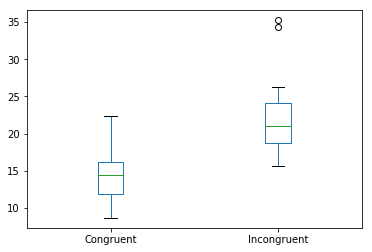

```python
#create box plot to visually compare the 2 scenarios
df.plot(kind='box')
```

I observe that the incongruent task has 2 extreme outliers that are much much higher than the rest of the times recorded. Also, the box plot as a whole starts at about the 75th percentile of the congruent box plot. This shows that the times recorded for the incongruent are much longer than those in the congruent task section.

(5) Now, perform the statistical test and report your results. What is your confidence level or Type I error associated with your test? What is your conclusion regarding the hypotheses you set up? Did the results match up with your expectations? **Hint:** Think about what is being measured on each individual, and what statistic best captures how an individual reacts in each environment.

#### Mean Difference

```python
df['Difference'] = df['Incongruent'] - df['Congruent']
mean_diff = df['Difference'].mean()
mean_diff
```

```
7.964791666666667
```

#### Standard Deviation and Standard Error of Mean Differences

```python
#standard deviation
std = df['Difference'].std(axis=0)
std
```

```
4.864826910359056
```

```python
#let's find the sample size and then subtract 1 to get the degree freedom
print(df['Congruent'].size)
print(df['Incongruent'].size)
```

```
24
24
```

```python
import math
```

```python
#standard error = std / sqrt(n)
SE = (std / math.sqrt(24))*mean_diff
SE
```

```
7.909266195043904
```

#### t-statistic

```python
#T = (mean diff) / (std / sqrt(size))
T = mean_diff/(std/(math.sqrt(24)))
T
```

```
8.020706944109957
```

degrees freedom (df) is going to be 24 - 1 = 23

#### t-critical value

```python
#confidence interval is 95%
#based on the sample size (degrees freedom) and confidence level, we can calculate the t-critical value
round(t.ppf(0.95, 23))
```

[output not shown]

I also found this in the t-table from the link in the resource section if you follow the table over, it shows a value of 1.714 for the t-critical.  
t-statistic > t-critical  
8.0207 > 1.714

8.0207 is greater than our critical value of 1.714 which means that we can reject our null hypothesis. This is what we would expect because identifying the congruent task took much less time that identifying the colors for the incongruent task. This theory even held true when I completed the task myself out of curiousity.

### Resources:

#### http://www.sjsu.edu/faculty/gerstman/StatPrimer/t-table.pdf